# STAT 578 - Fall 2019 - Assignment 5

Frederick (Eric) Ellwanger - fre2

November 23, 2019

## Exercise 1

```r
ozoneAQI <- read.table("ozoneAQIaug.txt", header=TRUE)
```

#### **(a) Let $\hat{\beta}_1^{(j)}$ and $\hat{\beta}_2^{(j)}$ be the *ordinary least squares* estimates of $\beta_1^{(j)}$ and $\beta_2^{(j)}$, estimated for city j. (The coeffcients are estimated completely separately for each city.)**

**(a)(i) Produce a scatterplot of the pairs $(\hat{\beta}_1^{(j)}, \hat{\beta}_2^{(j)})$, j = 1,…, 15.**

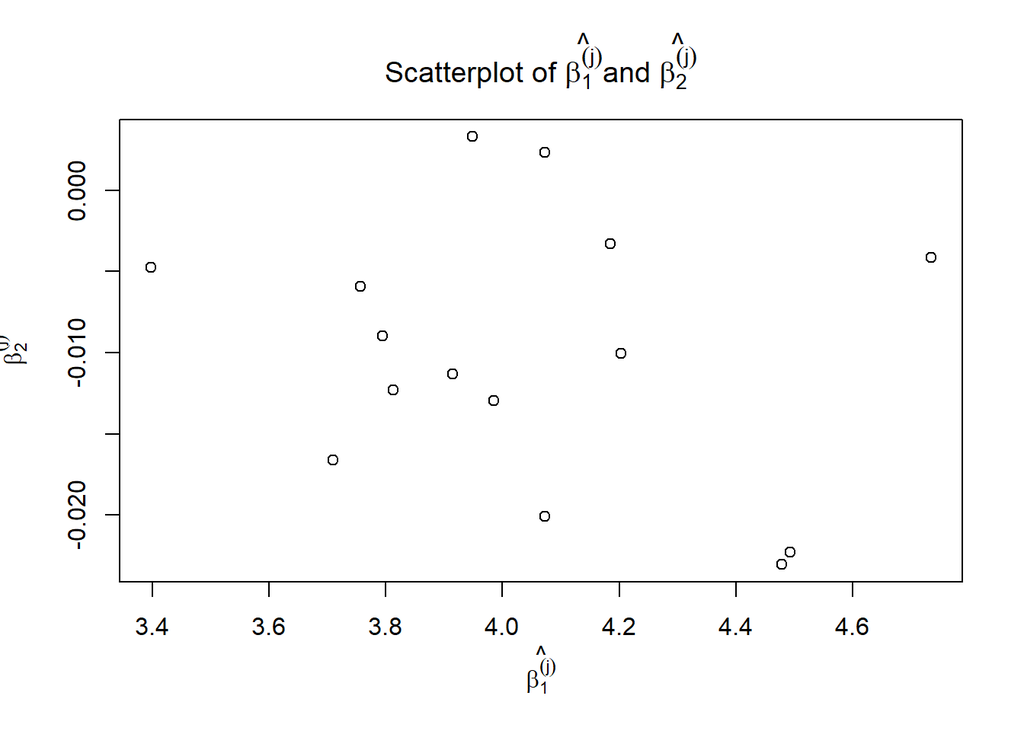

```r
betahat <- matrix(NA, nrow(ozoneAQI), 2)
for(j in 1:nrow(ozoneAQI)){
  betahat[j,] <- lsfit(cbind(1:31) - mean(1:31), t(log(ozoneAQI[j,])))$coef
}
plot(betahat[,2] ~ betahat[,1],
     main = expression(paste("Scatterplot of ", hat(beta[1]^(j)), "and ", hat(beta[2]^(j)))),
     xlab = expression(hat(beta[1]^(j))), ylab = expression(hat(beta[2]^(j))))
```

**(a)(ii) Compute the average (sample mean) of $\hat{\beta}_1^{(j)}$ and also of $\hat{\beta}_2^{(j)}$.**

```r
(bmean = apply(betahat, 2, mean))
```

```
## [1]  4.04 -0.01
```

mean of $\hat{\beta}_1^{(j)} \approx$ 4.037  
mean of $\hat{\beta}_2^{(j)} \approx$ -0.01

**(a)(iii) Compute the sample variance of $\hat{\beta}_1^{(j)}$ and also of $\hat{\beta}_2^{(j)}$.**

```r
var(betahat)
```

```
##           [,1]       [,2]
## [1,]  0.119406 -0.0006552
## [2,] -0.000655  0.0000668
```

**(a)(iv) Compute the sample correlation between $\hat{\beta}_1^{(j)}$ and $\hat{\beta}_2^{(j)}$.**

```r
(bcor = cor(betahat[,1], betahat[,2]))
```

```
## [1] -0.232
```

sample correlation between $\hat{\beta}_1^{(j)}$ and $\hat{\beta}_2^{(j)} \approx$ -0.232

**(b)(i) List an appropriate JAGS model. Make sure to create nodes for $\sum_\beta$, $\rho$, and $\sigma_y^2$. Remember that the ozone AQI values are to be analyzed on the log scale. Now run your model using rjags. Make sure to use multiple chains with overdispersed starting points, check convergence, and monitor $\mu_\beta$, $\sum_\beta$, $\sigma_y^2$, $\rho$ (after convergence) long enough to obtain effective sample sizes of at least 4000 for each parameter.**

```
data {
   dimY <- dim(logozone)
   daycent <- day - mean(day)
   }

   model {
      for (j in 1:dimY[1]) {
         for (i in 1:dimY[2]) {
            logozone[j,i] ~ dnorm(beta[1,j] + beta[2,j]*daycent[i], sigmasqyinv)
         }
         beta[1:2,j] ~ dmnorm(mubeta, Sigmabetainv)
       }

   mubeta ~ dmnorm(mubeta0, Sigmamubetainv)
   Sigmabetainv ~ dwish(2*Sigma0, 2)
   sigmasqyinv ~ dgamma(0.0001, 0.0001)
   Sigmabeta <- inverse(Sigmabetainv)
   rho <- Sigmabeta[1,2] / sqrt(Sigmabeta[1,1] * Sigmabeta[2,2])
   sigmasqy <- 1/sigmasqyinv
}
```

```r
ozone = read.table("ozoneAQIaug.txt", header = TRUE)
```

```r
library(rjags)
d1 <- list(logozone = log(ozone[,c(1:31)]), day = c(1:31), mubeta0 = c(0, 0),
           Sigmamubetainv = rbind(c(0.000001, 0), c(0, 0.000001)),
           Sigma0 = rbind(c(100, 0), c(0, 0.1)))
#Set overdispersed starting points
inits1 <- list(list(sigmasqyinv = 10, mubeta = c(100, 100),
                    Sigmabetainv = rbind(c(100, 0), c(0, 100))),
               list(sigmasqyinv = 0.001, mubeta = c(-100, 100),
                    Sigmabetainv = rbind(c(100, 0), c(0, 100))),
               list(sigmasqyinv = 10, mubeta = c(100, -100),
                    Sigmabetainv = rbind(c(0.001, 0), c(0, 0.001))),
               list(sigmasqyinv = 0.001, mubeta = c(-100, -100),
                    Sigmabetainv = rbind(c(0.001, 0),c(0, 0.001))))
#Setup model
m1 <- jags.model("ozone1.bug", d1, inits1, n.chains=4, n.adapt=2000)
```

```
## Compiling data graph
##    Initializing
##    Reading data back into data table
##
```

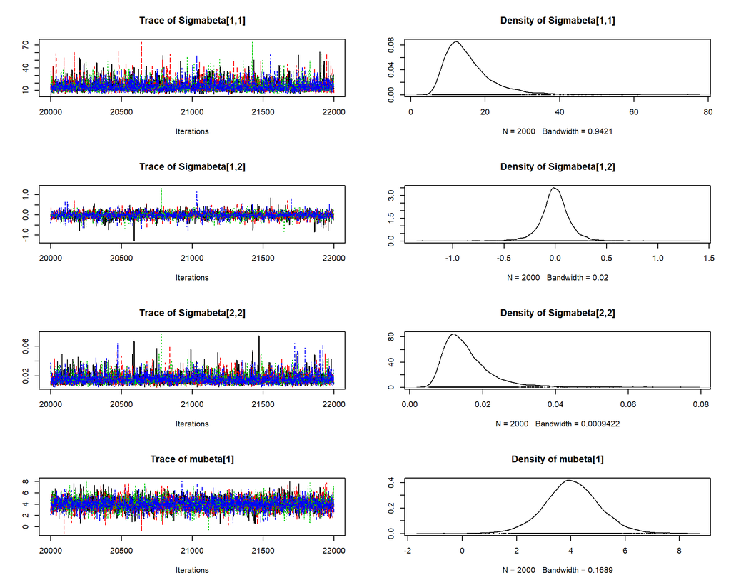

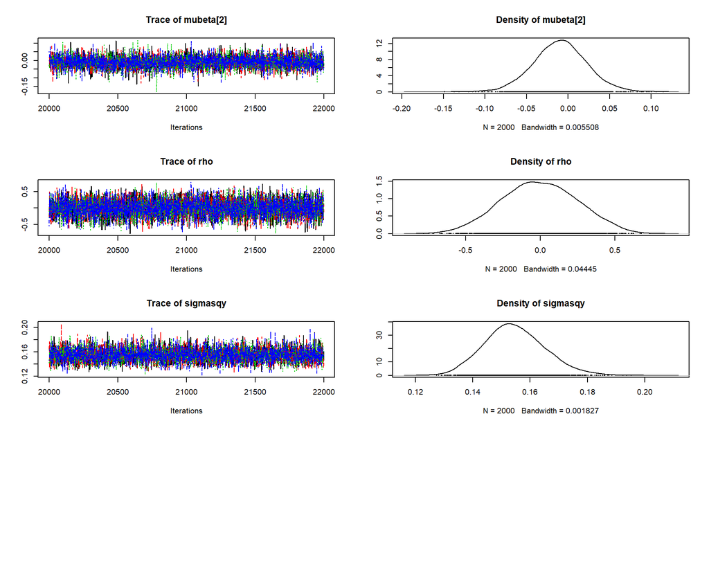

```r
#Burn-in
update(m1, 20000)
#Run model
x1 <- coda.samples(m1, c("mubeta[1]","mubeta[2]","Sigmabeta[1,1]","Sigmabeta[1,2]",
                   "Sigmabeta[2,2]","sigmasqy","rho"), n.iter=2000)
#Check for convergence
plot(x1, smooth = FALSE)
```

```r
#Another check for convergence
gelman.diag(x1, autoburnin=FALSE, multivariate=FALSE)
```

```
## Potential scale reduction factors:
##
##                Point est. Upper C.I.
## Sigmabeta[1,1]          1          1
## Sigmabeta[1,2]          1          1
## Sigmabeta[2,2]          1          1
## mubeta[1]               1          1
## mubeta[2]               1          1
## rho                     1          1
## sigmasqy                1          1
```

```r
#Another check for convergence and Neff > 4000/parameter
effectiveSize(x1[,c("mubeta[1]","mubeta[2]","Sigmabeta[1,1]","Sigmabeta[1,2]",
                    "Sigmabeta[2,2]","sigmasqy","rho")])
```

```
##      mubeta[1]      mubeta[2] Sigmabeta[1,1] Sigmabeta[1,2] Sigmabeta[2,2]
##           8000           8000           6959           6332           7183
##       sigmasqy            rho
##           7272           6117
```

**There does not appear to be any issues with convergance and all monitored parameters exceed an effective sample size of 4000**

**(b)(ii) Display the coda summary of the results for the monitored parameters.**

```r
(x1sum = summary(x1))
```

[output not shown]

**(b)(iii) Give an approximate 95% central posterior credible interval for the correlation parameter $\rho$, and also produce a graph of its (estimated) posterior density.**

```r
(rhostats = x1sum$quantiles["rho", c("2.5%", "97.5%")])
```

```
##   2.5%  97.5%
## -0.497  0.482
```

**The 95% central posterior credible interval, for $\rho$ is (-0.497, 0.482)**

**(b)(iv) Approximate the posterior probability that $\rho$ > 0. Also, compute the Bayes factor favoring $\rho$ > 0 versus $\rho$ < 0. (You may use the fact that $\rho$ > 0 and $\rho$ < 0 have equal prior probability.) Describe the level of data evidence that $\rho$ > 0.**

```r
rho.sim = as.matrix(x1)[, "rho"]
mean(rho.sim > 0)
```

```
## [1] 0.488
```

**The approximate posterior probability that $\rho>0 \approx$ 0.488**

```r
#Since PR_prior_h1 = PR_prior_h2 we divide by 1
(BF = (mean(rho.sim > 0)/mean(rho.sim < 0))/1)
```

```
## [1] 0.954
```

**The Bayes Factor is approximately 0.954. This is at a barely mentionable level on the Bayes Factor scale, suggesting there isn’t much evidence to support that $\rho > 0$**

**(b)(v) Your model implies that, over the 30-day period from the first day of August to the last, the (population) median ozone AQI value should have changed by a factor of:**

**$e^{30\mu_{\beta2}}$**

**Form an approximate 95% central posterior credible interval for this quantity.**

**(b)(v)**

```r
#use mubeta2 95% interval exp() to get data
(mu2q = exp(30*x1sum$quantiles["mubeta[2]", c("2.5%", "97.5%")]))
```

```
##  2.5% 97.5%
## 0.111 5.193
```

**The 95% central posterior credible interval, for this quantity is (0.111, 5.193)**

**(b)(vi) Use the rjags function dic.samples to compute the effective number of parameters (“penalty”) and Plummer’s DIC (“Penalized deviance”). Use at least 100,000 iterations.**

```r
#Find Effective No Parameters and Plummrs Deviance
load.module("dic")
(dev1 = dic.samples(m1, 100000))
```

```
## Mean deviance:  451
## penalty 31.1
## Penalized deviance: 482
```

**(c) Now consider a different model with “univariate” hyperpriors for the model coeffcients, which do not allow for a coeffcient correlation parameter.**

**(c)(i) Draw a complete DAG for this new model.**

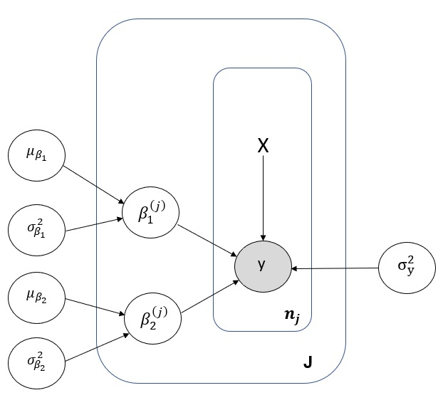

**(ii) List an appropriate JAGS model. Make sure that there are nodes for $\sigma_{\beta_1}^2$, $\sigma_{\beta_2}^2$, and $\sigma_y^2$.**

```
data {
   dimY <- dim(logozone)
   daycent <- day - mean(day)
}

model {
   for (j in 1:dimY[1]) {
      for (i in 1:dimY[2]) {
         logozone[j,i] ~ dnorm(beta[1,j] + beta[2,j]*daycent[i], sigmasqyinv)
      }
      beta[1,j] ~ dnorm(mubeta1, Sigmabeta1inv)
      beta[2,j] ~ dnorm(mubeta2, Sigmabeta2inv)
   }
   mubeta1 ~ dnorm(0, 1/(1000^2))
   mubeta2 ~ dnorm(0, 1/(1000^2))
   Sigmabeta1inv ~ dunif(0, 1000)
   Sigmabeta2inv ~ dunif(0, 1000)
   sigmasqyinv ~ dgamma(0.0001, 0.0001)

   Sigmabeta1 <- 1/Sigmabeta1inv
   Sigmabeta2 <- 1/Sigmabeta2inv
   sigmasqy <- 1/sigmasqyinv
}
```

**Remember that the ozone AQI values are to be analyzed on the log scale.**

```r
d2 <- list(logozone = log(ozone[,c(1:31)]), day = c(1:31))
```

**Now run your model using rjags. Make sure to use multiple chains with overdispersed starting points, check convergence, and monitor $\mu_{\beta_1}$, $\mu_{\beta_2}$, $\sigma_{\beta_1}^2$, $\sigma_{\beta_2}^2$, and $\sigma_y^2$ (after convergence) long enough to obtain effective sample sizes of at least 4000 for each parameter.**

```r
#Set overdispersed starting points
inits2 <- list(list(sigmasqyinv = 10, mubeta1 = 100, mubeta2 = -100,
                    Sigmabeta1inv = 10, Sigmabeta2inv = 10),
               list(sigmasqyinv = 0.001, mubeta1 = -100, mubeta2 = 100,
                    Sigmabeta1inv = 100, Sigmabeta2inv = 100),
               list(sigmasqyinv = 10, mubeta1 = 100, mubeta2 = 100,
                    Sigmabeta1inv = 0.001, Sigmabeta2inv = 0.001),
               list(sigmasqyinv = 0.001, mubeta1 = -100, mubeta2 = -100,
                    Sigmabeta1inv = 0.001, Sigmabeta2inv = 0.001))
#Setup model
m2 <- jags.model("ozone2.bug", d2, inits2, n.chains=4, n.adapt=1000)
```

```
## Compiling data graph
##    Initializing
##    Reading data back into data table
##
```

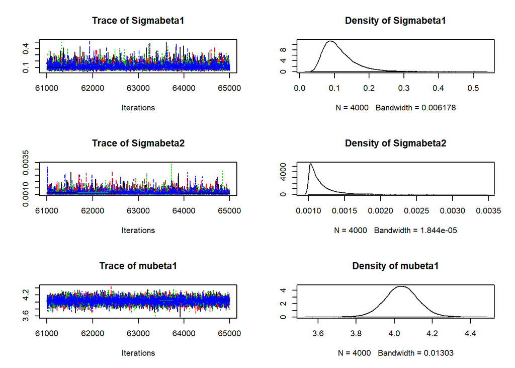

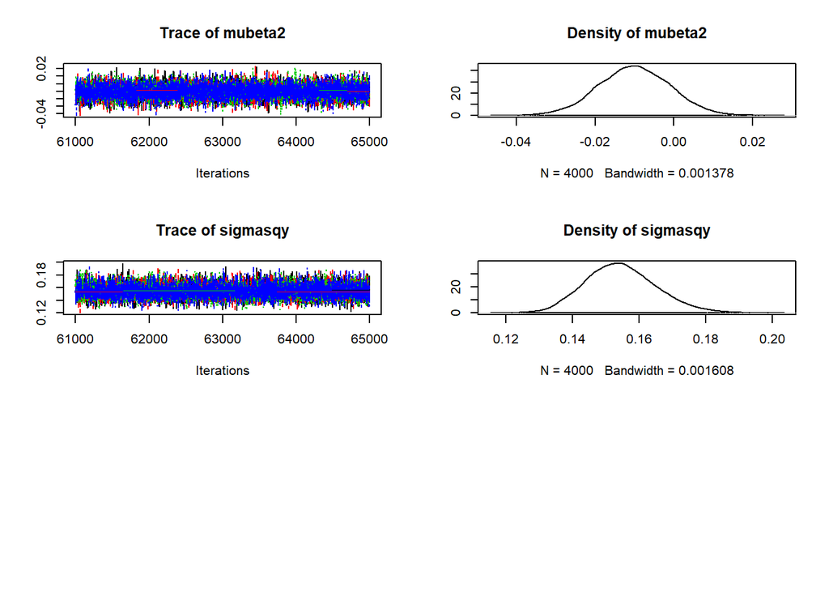

```r
#Burn-in
update(m2, 60000)
x2 <- coda.samples(m2, c("mubeta1","mubeta2", "Sigmabeta1","Sigmabeta2", "sigmasqy"), n.iter=4000)

#Check convergence
plot(x2)
```

```r
#Another check for convergence
gelman.diag(x2, autoburnin=FALSE, multivariate=FALSE)
```

```
## Potential scale reduction factors:
##
##            Point est. Upper C.I.
## Sigmabeta1          1          1
## Sigmabeta2          1          1
## mubeta1             1          1
## mubeta2             1          1
## sigmasqy            1          1
```

```r
#Another check for convergence and Neff > 4000/parameter
effectiveSize(x2[,c("mubeta1","mubeta2", "Sigmabeta1","Sigmabeta2", "sigmasqy")])
```

```
##    mubeta1    mubeta2 Sigmabeta1 Sigmabeta2   sigmasqy
##      14257      15250       9536       4419      13893
```

**There does not appear to be any issues with convergance and all monitored parameters exceed an effective sample size of 4000**

**(c)(iii) Display the coda summary of the results for the monitored parameters.**

```r
(sum2 = summary(x2))
```

```
##
## Iterations = 61001:65000
## Thinning interval = 1
## Number of chains = 4
## Sample size per chain = 4000
##
## 1. Empirical mean and standard deviation for each variable,
##    plus standard error of the mean:
##
##                Mean       SD   Naive SE Time-series SE
## Sigmabeta1  0.11366 0.048339 0.00038215     0.00050651
## Sigmabeta2  0.00115 0.000174 0.00000138     0.00000268
## mubeta1     4.03728 0.088831 0.00070227     0.00074442
## mubeta2    -0.01004 0.009012 0.00007125     0.00007306
## sigmasqy    0.15451 0.010514 0.00008312     0.00008929
##
## 2. Quantiles for each variable:
##
##               2.5%      25%     50%      75%   97.5%
## Sigmabeta1  0.0527  0.08051  0.1030  0.13464 0.23506
## Sigmabeta2  0.0010  0.00104  0.0011  0.00120 0.00161
## mubeta1     3.8616  3.98028  4.0367  4.09447 4.21399
## mubeta2    -0.0279 -0.01615 -0.0101 -0.00387 0.00754
## sigmasqy    0.1356  0.14714  0.1540  0.16128 0.17656
```

**(c)(iv) Recall the (population) median ozone AQI change factor $e^{30\mu_{\beta_2}}$ considered in the previous analysis. Form an approximate 95% central posterior credible interval for this quantity, and compare it with the previous results.**

```r
#use mubeta2 95% interval exp() to get data
(q95 = exp(sum2$quantiles["mubeta2", c("2.5%", "97.5%")]))
```

```
##  2.5% 97.5%
## 0.973 1.008
```

**This interval is much tighter than the interval from the previous results, although this interval is within the interval from the previous results**

**(c)(v) Use the rjags function dic.samples to compute the effective number of parameters (“penalty”) and Plummer’s DIC (“Penalized deviance”). Use at least 100,000 iterations.**

```r
(dev2 = dic.samples(m2, 100000))
```

```
## Mean deviance:  450
## penalty 29.8
## Penalized deviance: 480
```

**(c)(vi) Compare the (Plummer’s) DIC values for this model and the previous one. Which is preferred?**

```r
if((sum(dev1$deviance) - sum(dev2$deviance)) > 0){
  winner = "Part C Model"
}else{
  winner = "Part B Model"
}
```

**The model with the lowest DIC is preffered, therefore Part C Model is preffered**

**(d)(ii) It is possible that there are time-series correlations in the successive log-values of each city that are not captured by the simple linear regression model. What specific model assumption would this violate? (Is i or j involved?)**

**This would violate the exchangeability asumption of the response values within a city. If there was correlations not captured by the simple linear regression model, the individual data values will not be conditionally iid and they would also not be exchangeable.Since this effects the responses within a city, i would be involved**

**(d)(iii) It is possible that there are spatial correlations among the log-values on a given day that are not captured by the simple linear regression model (because some cities are closer to each other than others). What specific model assumption would this violate? (Is i or j involved?)**

**This would violate the iid assumption of the distribution of the $\beta_j's$. If there was some spatial correlation between the reponses between 2 cities that is not captured in the simple linear regression model, the $\beta_j's$ would no longer be iid or exchangeable. Since this effects the the responses between cities, j would be involved**